## Analyzing and Visualizing Data

# Introduction

This project is based on the twitter account @WeRateDogs. Here users post dogs pictures and rate them and make funny comments about the pictures. Rating is out of ten but some rating exceeds more according to pictures of dogs. In my project, I focused to see the most popular breed of dogs, dog categories, dog rates and dog names and dog stages.

#### https://twitter.com/dog_rates

## All Possible Correlations

First of all, I have to create the correlation matrix to know more about the trends between the retweet count, rating, and favorite count. It tells us can rating influence popularity or the number of retweets. According to the matrix, there is no correlation between rating, favorite count and retweet count, Which is right because sometimes the rating is out of 10 but most of the time its just the part of the joke so it can be random and make no correlation with anything. We can have a correlation between favorite count and retweet count because of the number of retweets the number of favorites.

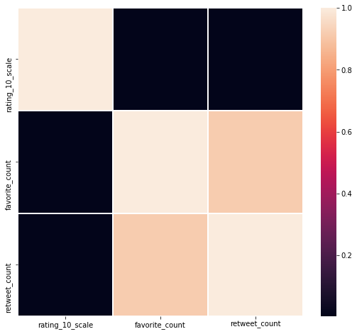

There is a correlation between favorite count and retweet count, it's like more retweet means more favorites. There is also no correlation between rating and favorite count and retweet count because it won't make any sense.  
A task for analysis:-

- To find the most popular and loved dog breeds.
- Most popular dog names in the dataset
- Dog Stages

#### 1. Most Popular Dog Names on the Account

As I saw earlier in the matrix that the rating has not any relationship with popularity so I want to find the most popular dog names. To find that I will rate popularity by the number of tweets, assuming that the most popular dog is supposed to appear more times on the page.

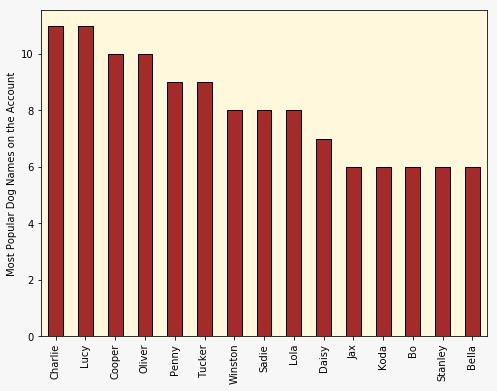

#### 2. Most Beloved Dog Breeds

To find out which dog is most beloved I use last analyze where I did the analysis the relationship between the number of favorite and dog bread to find the which dog breeds are the most beloved by the users. As result, I found that Golden Retrievers are most beloved dogs among all the dogs.

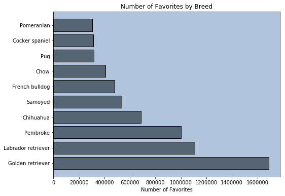

#### 3. Dog Stages

Here is the pie chart of Dog Stages without the missing values to make an analysis of the proportion of the categories.

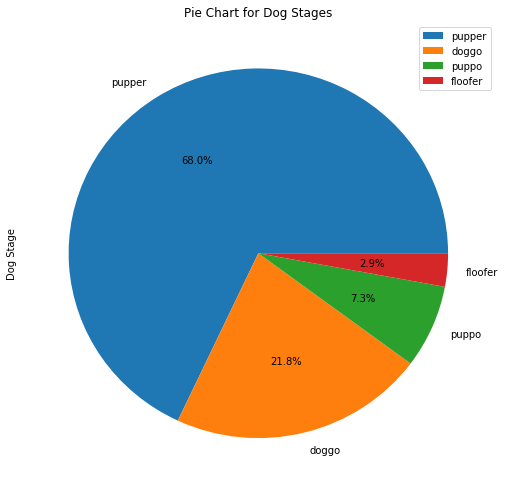

# **some pictures and funny comments from my analysis and from the twitter account WeRateDog @dog_rates**

[figure not shown]

[figure not shown]

[figure not shown]

[figure not shown]

# Conclusion

After all the analysis we got some very interesting relationships and fact which shows why this account having that many followers and when I personally go through this page in twitter I really enjoyed all cute dogs pictures and the funny comments. All through the rating in never be show the cuteness of the dog, they all are so amazing we really just don't count them in numbers.